# Gradiente descendente usando ejemplos

Sandoval-Pineda Cristian

6/8/2019

# 1 Función de una variable

Minimizar $x$ en $x²$  
Donde: $x \in I\!R$

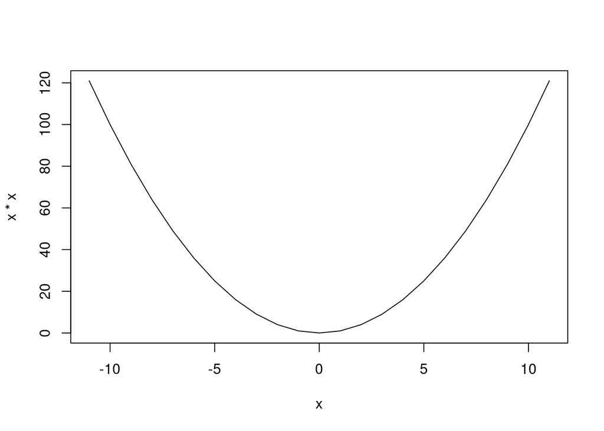

Figure 1.1: f(x) = x²

## 1.1 Qué se necesita.

Para encontrar un mínimo (o un máximo, en realidad es lo mismo cambiando un signo) usando *Gradiente Descendente* se necesita:  
**1.** La función a optimizar: $f( x )$  
**2.** La derivada (gradiente) de $f( x ) => f'( x )$  
**3.** Un parámetro llamado *alfa* o también mal llamado *tasa de aprendizaje* para que suene cool en el contexto de *aprendizaje de máquina*.  
**4.** Un criterio de parada.  
**5.** Un *punto* inicial $x_0$.

## 1.2 Para este simple caso se define cada item.

**1.** La función a optimizar: $f( x )$
$$f( x ) = x²$$
**2.** La derivada (gradiente) de $f( x ) => f'( x )$
$$f'( x ) = 2x$$
**3.** Un parámetro *alfa*.
$$\alpha = 0.1$$
**4.** Un criterio de parada: **cuando se haya iterado 100 veces.**
**5.** Un *punto* inicial:
$$x_0 = 10$$
.

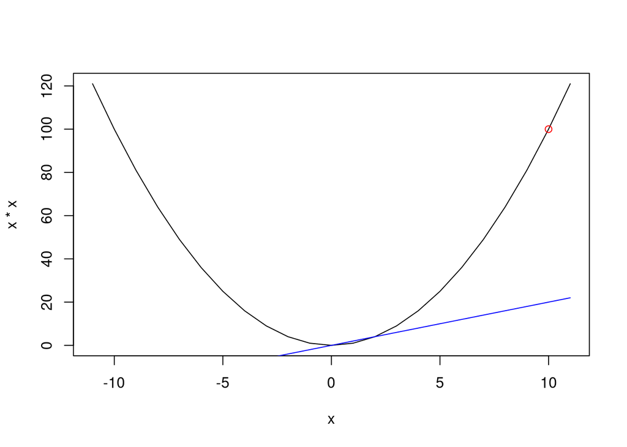

Figure 1.2: **En negro**: $f(x) = x²$; **En azul**: $f'(x) = 2x$; **En rojo**: $x_0 = 10$

## 1.3 Se calcula el $x_{i+1}$.

$$x_1 = x_0 - \alpha*f'(x_0)$$
$$x_1 = 10 - 0.1 * (2*10)$$
$$======> x_1 = 8$$

$$x_2 = x_1 - \alpha*f'(x_1)$$
$$x_2 = 8 - 0.1 * (2*8)$$
$$======> x_2 = 6.4$$
$$x_3 = x_2 - \alpha*f'(x_2)$$
$$x_3 = 6.4 - 0.1 * (2*6.4)$$
$$======> x_3 = 5.12$$
$$.$$
$$.$$
$$.$$

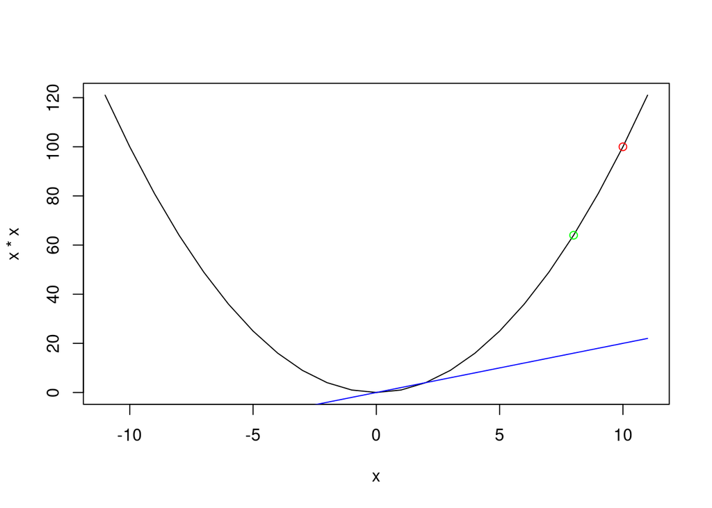

Figure 1.3: **En negro**: $f(x) = x²$; **En azul**: $f'(x) = 2x$; **En rojo**: $x_0 = 10$; **En verde**: $x_1$

## 1.4 Se calcula el $x_{i+1}$ hasta 100.

**Iteration**: 1 ======> **$x_{1}$** = 8.000000  
**Iteration**: 2 ======> **$x_{2}$** = 6.400000  
**Iteration**: 3 ======> **$x_{3}$** = 5.120000  
**Iteration**: 4 ======> **$x_{4}$** = 4.096000  
**Iteration**: 5 ======> **$x_{5}$** = 3.276800  
**Iteration**: 6 ======> **$x_{6}$** = 2.621440  
**Iteration**: 7 ======> **$x_{7}$** = 2.097152  
**Iteration**: 8 ======> **$x_{8}$** = 1.677722  
**Iteration**: 9 ======> **$x_{9}$** = 1.342177  
**Iteration**: 10 ======> **$x_{10}$** = 1.073742  
**Iteration**: 11 ======> **$x_{11}$** = 0.858993  
**Iteration**: 12 ======> **$x_{12}$** = 0.687195  
**Iteration**: 13 ======> **$x_{13}$** = 0.549756  
**Iteration**: 14 ======> **$x_{14}$** = 0.439805  
**Iteration**: 15 ======> **$x_{15}$** = 0.351844  
**Iteration**: 16 ======> **$x_{16}$** = 0.281475  
**Iteration**: 17 ======> **$x_{17}$** = 0.225180  
**Iteration**: 18 ======> **$x_{18}$** = 0.180144  
**Iteration**: 19 ======> **$x_{19}$** = 0.144115  
**Iteration**: 20 ======> **$x_{20}$** = 0.115292  
**Iteration**: 21 ======> **$x_{21}$** = 0.092234  
**Iteration**: 22 ======> **$x_{22}$** = 0.073787  
**Iteration**: 23 ======> **$x_{23}$** = 0.059030  
**Iteration**: 24 ======> **$x_{24}$** = 0.047224  
**Iteration**: 25 ======> **$x_{25}$** = 0.037779  
**Iteration**: 26 ======> **$x_{26}$** = 0.030223  
**Iteration**: 27 ======> **$x_{27}$** = 0.024179  
**Iteration**: 28 ======> **$x_{28}$** = 0.019343  
**Iteration**: 29 ======> **$x_{29}$** = 0.015474  
**Iteration**: 30 ======> **$x_{30}$** = 0.012379  
**Iteration**: 31 ======> **$x_{31}$** = 0.009904  
**Iteration**: 32 ======> **$x_{32}$** = 0.007923  
**Iteration**: 33 ======> **$x_{33}$** = 0.006338  
**Iteration**: 34 ======> **$x_{34}$** = 0.005071  
**Iteration**: 35 ======> **$x_{35}$** = 0.004056  
**Iteration**: 36 ======> **$x_{36}$** = 0.003245  
**Iteration**: 37 ======> **$x_{37}$** = 0.002596  
**Iteration**: 38 ======> **$x_{38}$** = 0.002077  
**Iteration**: 39 ======> **$x_{39}$** = 0.001662  
**Iteration**: 40 ======> **$x_{40}$** = 0.001329  
**Iteration**: 41 ======> **$x_{41}$** = 0.001063  
**Iteration**: 42 ======> **$x_{42}$** = 0.000851  
**Iteration**: 43 ======> **$x_{43}$** = 0.000681  
**Iteration**: 44 ======> **$x_{44}$** = 0.000544  
**Iteration**: 45 ======> **$x_{45}$** = 0.000436  
**Iteration**: 46 ======> **$x_{46}$** = 0.000348  
**Iteration**: 47 ======> **$x_{47}$** = 0.000279  
**Iteration**: 48 ======> **$x_{48}$** = 0.000223  
**Iteration**: 49 ======> **$x_{49}$** = 0.000178  
**Iteration**: 50 ======> **$x_{50}$** = 0.000143  
**Iteration**: 51 ======> **$x_{51}$** = 0.000114  
**Iteration**: 52 ======> **$x_{52}$** = 0.000091  
**Iteration**: 53 ======> **$x_{53}$** = 0.000073  
**Iteration**: 54 ======> **$x_{54}$** = 0.000058  
**Iteration**: 55 ======> **$x_{55}$** = 0.000047  
**Iteration**: 56 ======> **$x_{56}$** = 0.000037  
**Iteration**: 57 ======> **$x_{57}$** = 0.000030  
**Iteration**: 58 ======> **$x_{58}$** = 0.000024  
**Iteration**: 59 ======> **$x_{59}$** = 0.000019  
**Iteration**: 60 ======> **$x_{60}$** = 0.000015  
**Iteration**: 61 ======> **$x_{61}$** = 0.000012  
**Iteration**: 62 ======> **$x_{62}$** = 0.000010  
**Iteration**: 63 ======> **$x_{63}$** = 0.000008  
**Iteration**: 64 ======> **$x_{64}$** = 0.000006  
**Iteration**: 65 ======> **$x_{65}$** = 0.000005  
**Iteration**: 66 ======> **$x_{66}$** = 0.000004  
**Iteration**: 67 ======> **$x_{67}$** = 0.000003  
**Iteration**: 68 ======> **$x_{68}$** = 0.000003  
**Iteration**: 69 ======> **$x_{69}$** = 0.000002  
**Iteration**: 70 ======> **$x_{70}$** = 0.000002  
**Iteration**: 71 ======> **$x_{71}$** = 0.000001  
**Iteration**: 72 ======> **$x_{72}$** = 0.000001  
**Iteration**: 73 ======> **$x_{73}$** = 0.000001  
**Iteration**: 74 ======> **$x_{74}$** = 0.000001  
**Iteration**: 75 ======> **$x_{75}$** = 0.000001  
**Iteration**: 76 ======> **$x_{76}$** = 0.000000  
**Iteration**: 77 ======> **$x_{77}$** = 0.000000  
**Iteration**: 78 ======> **$x_{78}$** = 0.000000  
**Iteration**: 79 ======> **$x_{79}$** = 0.000000  
**Iteration**: 80 ======> **$x_{80}$** = 0.000000  
**Iteration**: 81 ======> **$x_{81}$** = 0.000000  
**Iteration**: 82 ======> **$x_{82}$** = 0.000000  
**Iteration**: 83 ======> **$x_{83}$** = 0.000000  
**Iteration**: 84 ======> **$x_{84}$** = 0.000000  
**Iteration**: 85 ======> **$x_{85}$** = 0.000000  
**Iteration**: 86 ======> **$x_{86}$** = 0.000000  
**Iteration**: 87 ======> **$x_{87}$** = 0.000000  
**Iteration**: 88 ======> **$x_{88}$** = 0.000000  
**Iteration**: 89 ======> **$x_{89}$** = 0.000000  
**Iteration**: 90 ======> **$x_{90}$** = 0.000000  
**Iteration**: 91 ======> **$x_{91}$** = 0.000000  
**Iteration**: 92 ======> **$x_{92}$** = 0.000000  
**Iteration**: 93 ======> **$x_{93}$** = 0.000000  
**Iteration**: 94 ======> **$x_{94}$** = 0.000000  
**Iteration**: 95 ======> **$x_{95}$** = 0.000000  
**Iteration**: 96 ======> **$x_{96}$** = 0.000000  
**Iteration**: 97 ======> **$x_{97}$** = 0.000000  
**Iteration**: 98 ======> **$x_{98}$** = 0.000000  
**Iteration**: 99 ======> **$x_{99}$** = 0.000000  
**Iteration**: 100 ======> **$x_{100}$** = 0.000000

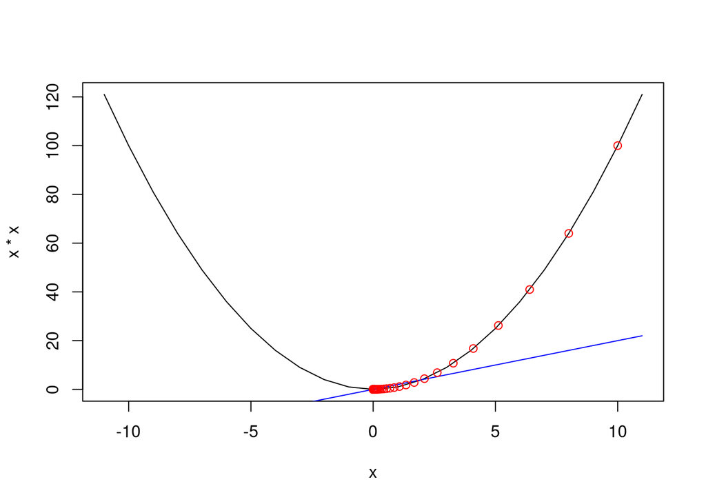

Figure 1.4: **En negro**: $f(x) = x²$; **En azul**: $f'(x) = 2x$; **En rojo**: todos los puntos $x_i$

# 2 Función de más de una variable

Minimizar $(x, y)$ en $x²+y²$  
Donde: $x \in I\!R$, $y \in I\!R$

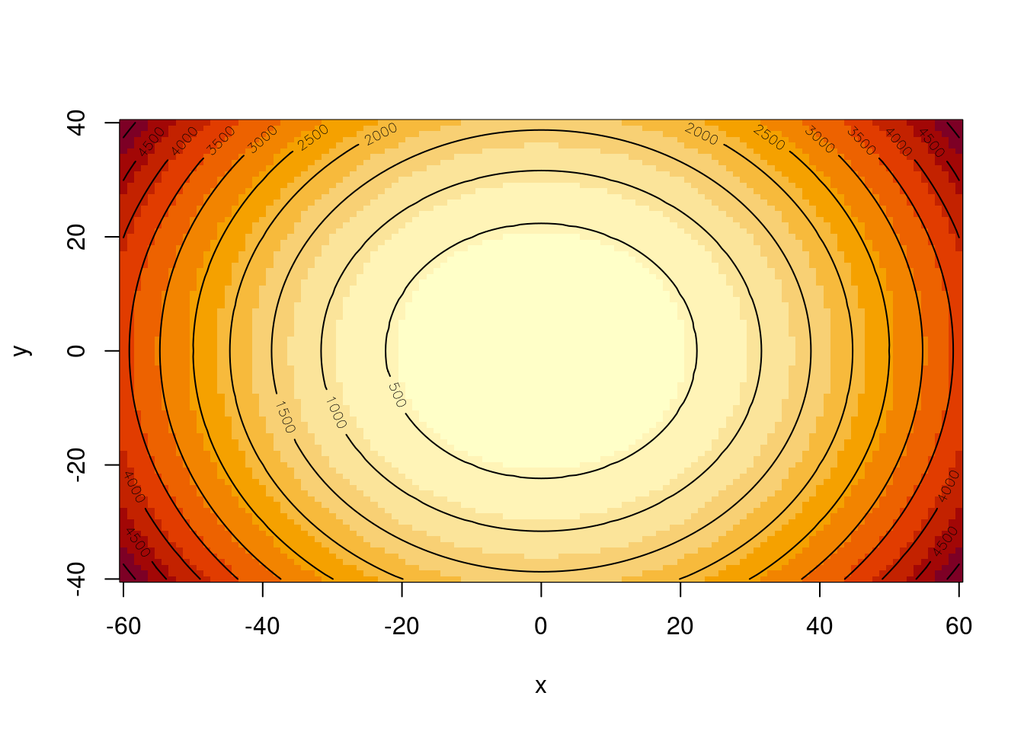

Figure 2.1: $f( x, y ) = x² + y²$

## 2.1 Para este simple caso se define cada item.

**1.** La función a optimizar: $f( x,y )$
$$f( x, y ) = x² + y² = z$$
**2.** El gradiente de $f( x, y ) => ( \frac{\partial z}{\partial x}, \frac{\partial z}{\partial y} )$
$$g( x, y ) = (2x,2y)$$
**3.** Un parámetro *alfa*.
$$\alpha = 0.1$$
**4.** Un criterio de parada: **cuando se haya iterado 100 veces.**
**5.** Un *punto* inicial:
$$(x_0, y_0) = (25, 35)$$
.

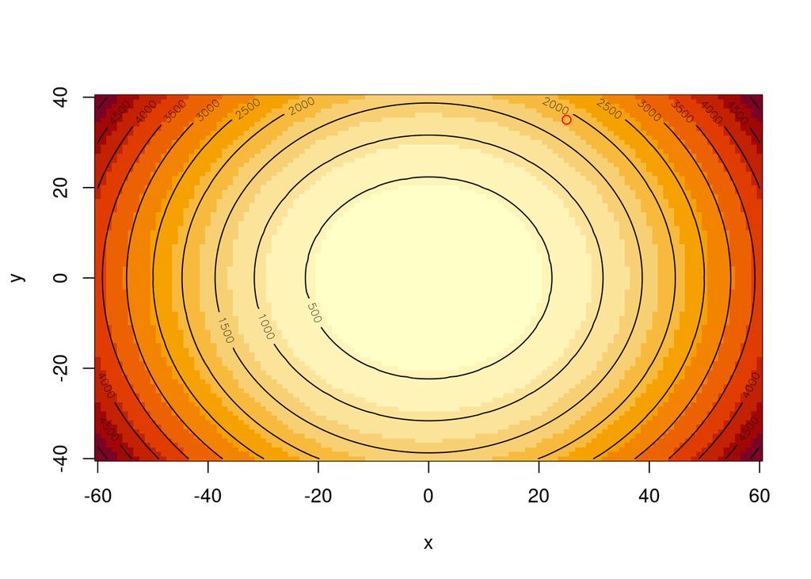

Figure 2.2: $f( x, y ) = x² + y²$; **punto rojo**: punto inicial (x_0, y_0)

## 2.3 Se calcula el $(x_{i+1}, y_{i+1})$ hasta 100.

**Iteration**: 1 ======> **$(x_{1}, y_{1})$** = (20.000000,28.000000)  
**Iteration**: 2 ======> **$(x_{2}, y_{2})$** = (16.000000,22.400000)  
**Iteration**: 3 ======> **$(x_{3}, y_{3})$** = (12.800000,17.920000)  
**Iteration**: 4 ======> **$(x_{4}, y_{4})$** = (10.240000,14.336000)  
**Iteration**: 5 ======> **$(x_{5}, y_{5})$** = (8.192000,11.468800)  
**Iteration**: 6 ======> **$(x_{6}, y_{6})$** = (6.553600,9.175040)  
**Iteration**: 7 ======> **$(x_{7}, y_{7})$** = (5.242880,7.340032)  
**Iteration**: 8 ======> **$(x_{8}, y_{8})$** = (4.194304,5.872026)  
**Iteration**: 9 ======> **$(x_{9}, y_{9})$** = (3.355443,4.697620)  
**Iteration**: 10 ======> **$(x_{10}, y_{10})$** = (2.684355,3.758096)  
**Iteration**: 11 ======> **$(x_{11}, y_{11})$** = (2.147484,3.006477)  
**Iteration**: 12 ======> **$(x_{12}, y_{12})$** = (1.717987,2.405182)  
**Iteration**: 13 ======> **$(x_{13}, y_{13})$** = (1.374390,1.924145)  
**Iteration**: 14 ======> **$(x_{14}, y_{14})$** = (1.099512,1.539316)  
**Iteration**: 15 ======> **$(x_{15}, y_{15})$** = (0.879609,1.231453)  
**Iteration**: 16 ======> **$(x_{16}, y_{16})$** = (0.703687,0.985162)  
**Iteration**: 17 ======> **$(x_{17}, y_{17})$** = (0.562950,0.788130)  
**Iteration**: 18 ======> **$(x_{18}, y_{18})$** = (0.450360,0.630504)  
**Iteration**: 19 ======> **$(x_{19}, y_{19})$** = (0.360288,0.504403)  
**Iteration**: 20 ======> **$(x_{20}, y_{20})$** = (0.288230,0.403523)  
**Iteration**: 21 ======> **$(x_{21}, y_{21})$** = (0.230584,0.322818)  
**Iteration**: 22 ======> **$(x_{22}, y_{22})$** = (0.184467,0.258254)  
**Iteration**: 23 ======> **$(x_{23}, y_{23})$** = (0.147574,0.206604)  
**Iteration**: 24 ======> **$(x_{24}, y_{24})$** = (0.118059,0.165283)  
**Iteration**: 25 ======> **$(x_{25}, y_{25})$** = (0.094447,0.132226)  
**Iteration**: 26 ======> **$(x_{26}, y_{26})$** = (0.075558,0.105781)  
**Iteration**: 27 ======> **$(x_{27}, y_{27})$** = (0.060446,0.084625)  
**Iteration**: 28 ======> **$(x_{28}, y_{28})$** = (0.048357,0.067700)  
**Iteration**: 29 ======> **$(x_{29}, y_{29})$** = (0.038686,0.054160)  
**Iteration**: 30 ======> **$(x_{30}, y_{30})$** = (0.030949,0.043328)  
**Iteration**: 31 ======> **$(x_{31}, y_{31})$** = (0.024759,0.034662)  
**Iteration**: 32 ======> **$(x_{32}, y_{32})$** = (0.019807,0.027730)  
**Iteration**: 33 ======> **$(x_{33}, y_{33})$** = (0.015846,0.022184)  
**Iteration**: 34 ======> **$(x_{34}, y_{34})$** = (0.012677,0.017747)  
**Iteration**: 35 ======> **$(x_{35}, y_{35})$** = (0.010141,0.014198)  
**Iteration**: 36 ======> **$(x_{36}, y_{36})$** = (0.008113,0.011358)  
**Iteration**: 37 ======> **$(x_{37}, y_{37})$** = (0.006490,0.009087)  
**Iteration**: 38 ======> **$(x_{38}, y_{38})$** = (0.005192,0.007269)  
**Iteration**: 39 ======> **$(x_{39}, y_{39})$** = (0.004154,0.005815)  
**Iteration**: 40 ======> **$(x_{40}, y_{40})$** = (0.003323,0.004652)  
**Iteration**: 41 ======> **$(x_{41}, y_{41})$** = (0.002658,0.003722)  
**Iteration**: 42 ======> **$(x_{42}, y_{42})$** = (0.002127,0.002977)  
**Iteration**: 43 ======> **$(x_{43}, y_{43})$** = (0.001701,0.002382)  
**Iteration**: 44 ======> **$(x_{44}, y_{44})$** = (0.001361,0.001906)  
**Iteration**: 45 ======> **$(x_{45}, y_{45})$** = (0.001089,0.001524)  
**Iteration**: 46 ======> **$(x_{46}, y_{46})$** = (0.000871,0.001220)  
**Iteration**: 47 ======> **$(x_{47}, y_{47})$** = (0.000697,0.000976)  
**Iteration**: 48 ======> **$(x_{48}, y_{48})$** = (0.000558,0.000781)  
**Iteration**: 49 ======> **$(x_{49}, y_{49})$** = (0.000446,0.000624)  
**Iteration**: 50 ======> **$(x_{50}, y_{50})$** = (0.000357,0.000500)  
**Iteration**: 51 ======> **$(x_{51}, y_{51})$** = (0.000285,0.000400)  
**Iteration**: 52 ======> **$(x_{52}, y_{52})$** = (0.000228,0.000320)  
**Iteration**: 53 ======> **$(x_{53}, y_{53})$** = (0.000183,0.000256)  
**Iteration**: 54 ======> **$(x_{54}, y_{54})$** = (0.000146,0.000205)  
**Iteration**: 55 ======> **$(x_{55}, y_{55})$** = (0.000117,0.000164)  
**Iteration**: 56 ======> **$(x_{56}, y_{56})$** = (0.000094,0.000131)  
**Iteration**: 57 ======> **$(x_{57}, y_{57})$** = (0.000075,0.000105)  
**Iteration**: 58 ======> **$(x_{58}, y_{58})$** = (0.000060,0.000084)  
**Iteration**: 59 ======> **$(x_{59}, y_{59})$** = (0.000048,0.000067)  
**Iteration**: 60 ======> **$(x_{60}, y_{60})$** = (0.000038,0.000054)  
**Iteration**: 61 ======> **$(x_{61}, y_{61})$** = (0.000031,0.000043)  
**Iteration**: 62 ======> **$(x_{62}, y_{62})$** = (0.000025,0.000034)  
**Iteration**: 63 ======> **$(x_{63}, y_{63})$** = (0.000020,0.000027)  
**Iteration**: 64 ======> **$(x_{64}, y_{64})$** = (0.000016,0.000022)  
**Iteration**: 65 ======> **$(x_{65}, y_{65})$** = (0.000013,0.000018)  
**Iteration**: 66 ======> **$(x_{66}, y_{66})$** = (0.000010,0.000014)  
**Iteration**: 67 ======> **$(x_{67}, y_{67})$** = (0.000008,0.000011)  
**Iteration**: 68 ======> **$(x_{68}, y_{68})$** = (0.000006,0.000009)  
**Iteration**: 69 ======> **$(x_{69}, y_{69})$** = (0.000005,0.000007)  
**Iteration**: 70 ======> **$(x_{70}, y_{70})$** = (0.000004,0.000006)  
**Iteration**: 71 ======> **$(x_{71}, y_{71})$** = (0.000003,0.000005)  
**Iteration**: 72 ======> **$(x_{72}, y_{72})$** = (0.000003,0.000004)  
**Iteration**: 73 ======> **$(x_{73}, y_{73})$** = (0.000002,0.000003)  
**Iteration**: 74 ======> **$(x_{74}, y_{74})$** = (0.000002,0.000002)  
**Iteration**: 75 ======> **$(x_{75}, y_{75})$** = (0.000001,0.000002)  
**Iteration**: 76 ======> **$(x_{76}, y_{76})$** = (0.000001,0.000002)  
**Iteration**: 77 ======> **$(x_{77}, y_{77})$** = (0.000001,0.000001)  
**Iteration**: 78 ======> **$(x_{78}, y_{78})$** = (0.000001,0.000001)  
**Iteration**: 79 ======> **$(x_{79}, y_{79})$** = (0.000001,0.000001)  
**Iteration**: 80 ======> **$(x_{80}, y_{80})$** = (0.000000,0.000001)  
**Iteration**: 81 ======> **$(x_{81}, y_{81})$** = (0.000000,0.000000)  
**Iteration**: 82 ======> **$(x_{82}, y_{82})$** = (0.000000,0.000000)  
**Iteration**: 83 ======> **$(x_{83}, y_{83})$** = (0.000000,0.000000)  
**Iteration**: 84 ======> **$(x_{84}, y_{84})$** = (0.000000,0.000000)  
**Iteration**: 85 ======> **$(x_{85}, y_{85})$** = (0.000000,0.000000)  
**Iteration**: 86 ======> **$(x_{86}, y_{86})$** = (0.000000,0.000000)  
**Iteration**: 87 ======> **$(x_{87}, y_{87})$** = (0.000000,0.000000)  
**Iteration**: 88 ======> **$(x_{88}, y_{88})$** = (0.000000,0.000000)  
**Iteration**: 89 ======> **$(x_{89}, y_{89})$** = (0.000000,0.000000)  
**Iteration**: 90 ======> **$(x_{90}, y_{90})$** = (0.000000,0.000000)  
**Iteration**: 91 ======> **$(x_{91}, y_{91})$** = (0.000000,0.000000)  
**Iteration**: 92 ======> **$(x_{92}, y_{92})$** = (0.000000,0.000000)  
**Iteration**: 93 ======> **$(x_{93}, y_{93})$** = (0.000000,0.000000)  
**Iteration**: 94 ======> **$(x_{94}, y_{94})$** = (0.000000,0.000000)  
**Iteration**: 95 ======> **$(x_{95}, y_{95})$** = (0.000000,0.000000)  
**Iteration**: 96 ======> **$(x_{96}, y_{96})$** = (0.000000,0.000000)  
**Iteration**: 97 ======> **$(x_{97}, y_{97})$** = (0.000000,0.000000)  
**Iteration**: 98 ======> **$(x_{98}, y_{98})$** = (0.000000,0.000000)  
**Iteration**: 99 ======> **$(x_{99}, y_{99})$** = (0.000000,0.000000)  
**Iteration**: 100 ======> **$(x_{100}, y_{100})$** = (0.000000,0.000000)

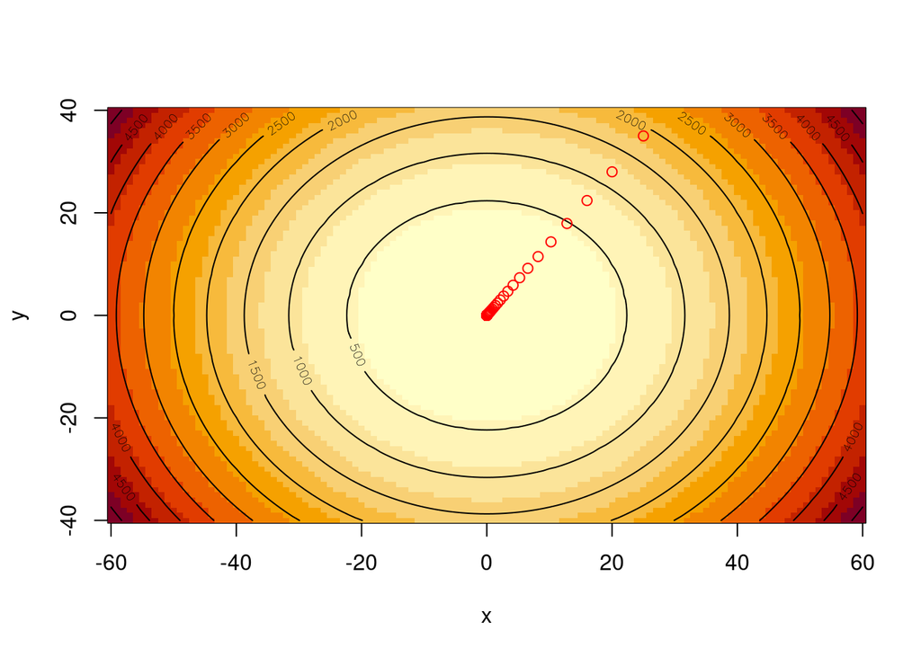

Figure 2.3: $f( x, y ) = x² + y²$; **puntos rojos**: puntos $(x_i, y_i)$

# 3 Minimizando el error de una “neurona”

### 3.0.1 Neurona simple

Una neurona artificial tiene la forma $f( x )= \phi(\sum {(w_i*x_i)})$ donde:  
- $x$ es un vector, $x \in I\!R^n$, llamado *vector de entrada*.  
- $w$ es un vector, $w \in I\!R^n$, llamado *vector de pesos*.  
- La función $\phi$ es la función llamada *función de activación* que puede ser sigmoidal, gaussiana, tangencial, entre otras.

Si se toma $x \in I\!R¹$, $w \in I\!R¹$ y $\phi(x) = tanh(x)$; entonces: $f( x ) = tanh( w * x )$.

### 3.0.2 Conjunto de datos de *entrenamiento*

Ahora a diferencia de los anteriores ejemplos, esta no es la función que se quiere optimizar, ya que se quiere minimizar un error que es, por lo general, la “neurona” evaluada en un conjunto de puntos de los cuales se conoce su valor esperado, por ejemplo:

```
##       x           y
## 1  -2.0 -0.83910157
## 2  -1.8 -0.88080332
## 3  -1.6 -0.84034692
## 4  -1.4 -0.77191939
## 5  -1.2 -0.70035718
## 6  -1.0 -0.63097096
## 7  -0.8 -0.45121667
## 8  -0.6 -0.42935439
## 9  -0.4 -0.21375027
## 10 -0.2 -0.16600205
## 11  0.0 -0.03546570
## 12  0.2  0.09398273
## 13  0.4  0.22651220
## 14  0.6  0.34201223
## 15  0.8  0.45652401
## 16  1.0  0.62098732
## 17  1.2  0.70601469
## 18  1.4  0.68847401
## 19  1.6  0.75091096
## 20  1.8  0.88394254
## 21  2.0  0.82530171
```

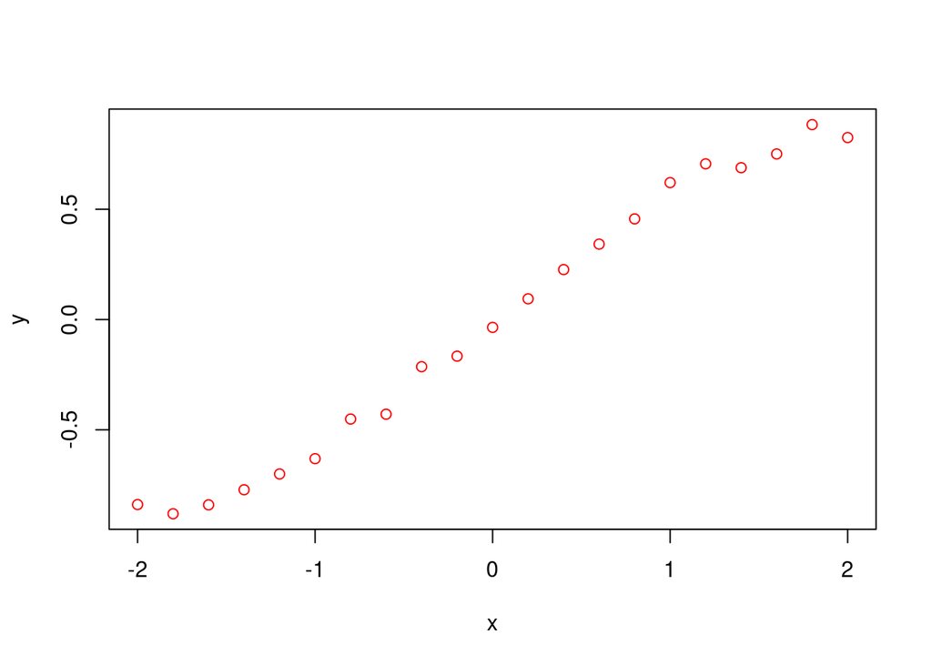

Figure 3.1: Función a aproximar con la neurona

### 3.0.3 Definiendo el problema de optimización

Ahora, si se define el error como, el error de la neurona dado el conjunto de pesos $w$ (en este caso $w$ sólo es un escalar):
$$Error(w) = \frac{1}{2}(y_0 - f(x_0))^2 + \frac{1}{2}(y_1 - f(x_1))^2 + \dots + \frac{1}{2}(y_n - f(x_n))^2$$
$$Error(w) = \frac{1}{2}\sum{(y_i - f(x_i))^2}$$
$$Error(w) = \frac{1}{2}\sum{(y_i - tanh(w*x_i))^2}$$

**El problema de optimización ya puede ser definido:**

Minimizar $w$ en $\frac{1}{2}\sum{(y_i - tanh(w*x_i))^2}$  
Donde: $w \in I\!R^1$

### 3.0.4 Resolviendo el problema de optimización

**Se calcula el $w_{i+1}$.**

```
##       x           y     neuron   Diferencia
## 1  -2.0 -0.78176234 -0.8253029  0.043540515
## 2  -1.8 -0.76042516 -0.7840901  0.023664943
## 3  -1.6 -0.69556227 -0.7345687  0.039006394
## 4  -1.4 -0.65874167 -0.6757532  0.017011555
## 5  -1.2 -0.75627130 -0.6068590 -0.149412263
## 6  -1.0 -0.53352433 -0.5274544 -0.006069895
## 7  -0.8 -0.40209540 -0.4376250  0.035529638
## 8  -0.6 -0.30155551 -0.3381189  0.036563402
## 9  -0.4 -0.19365143 -0.2304311  0.036779709
## 10 -0.2 -0.21210662 -0.1167870 -0.095319606
## 11  0.0  0.09609953  0.0000000  0.096099528
## 12  0.2  0.03499911  0.1167870 -0.081787908
## 13  0.4  0.35953197  0.2304311  0.129100829
## 14  0.6  0.31413755  0.3381189 -0.023981363
## 15  0.8  0.55455407  0.4376250  0.116929033
## 16  1.0  0.52407563  0.5274544 -0.003378802
## 17  1.2  0.60841985  0.6068590  0.001560818
## 18  1.4  0.79305145  0.6757532  0.117298227
## 19  1.6  0.87320773  0.7345687  0.138639066
## 20  1.8  0.77841169  0.7840901 -0.005678411
## 21  2.0  0.77978413  0.8253029 -0.045518731
```

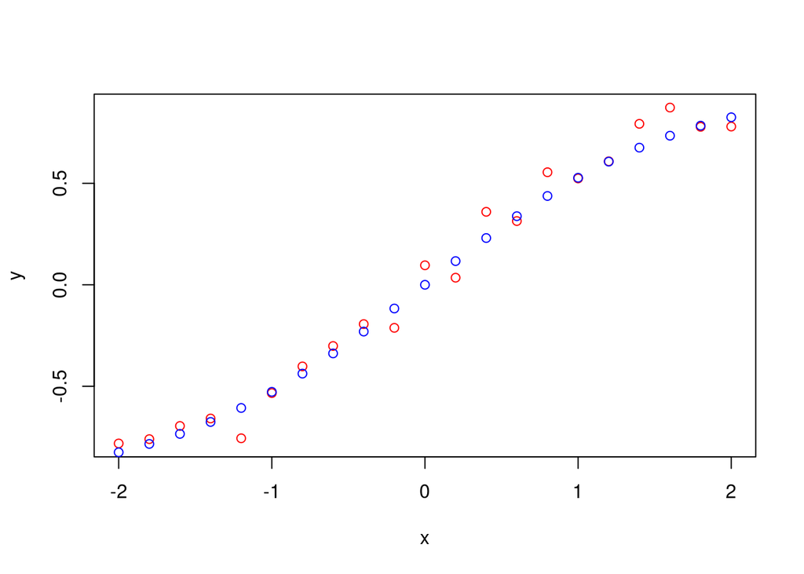

Figure 3.2: **En rojo:** función a aproximar; **En azul:** Función aproximada con una neurona